# Importaciones

Marco Ramirez, Estuardo Hernandez

2022-08-02

```r
# libreria
library("readxl")
library(ggplot2)

# xls files
importacion <- read_excel("importacion.xlsx")
importacion$Fecha<-as.Date(importacion$Fecha, "%Y/%m/%d")
```

## Importaciones

El dataset de importaciones cuenta con 257 filas y 4 las cuales son las siguientes

```r
str(importacion)
```

```
## tibble [257 x 4] (S3: tbl_df/tbl/data.frame)
##  $ Fecha             : Date[1:257], format: "2001-01-01" "2001-02-01" ...
##  $ Gasolina superior : num [1:257] 373964 243091 312084 285055 300914 ...
##  $ Gasolina regular  : num [1:257] 177777 123116 161726 127339 168730 ...
##  $ Diesel alto azufre: num [1:257] 566102 489526 575560 437745 552609 ...
```

Los datos almacenados en la base de datos son los siguientes: * Fecha=continua * Gasolina superior = Cuantitativa continua * Gasolina regular = Cuantitativa continua * Diesel alto azufre = Cuantitativa continua

La variable gasolina superior tiene el siguiente comportamiento:

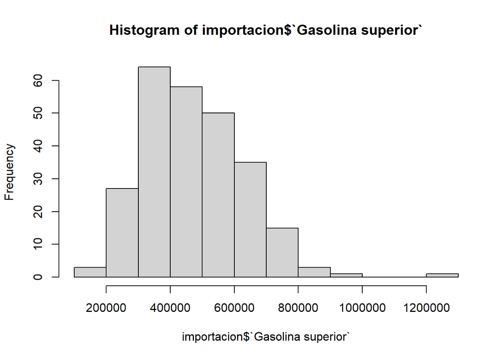

```r
hist(x = importacion$`Gasolina superior`)
```

La variable gasolina regular tiene el siguiente comportamiento:

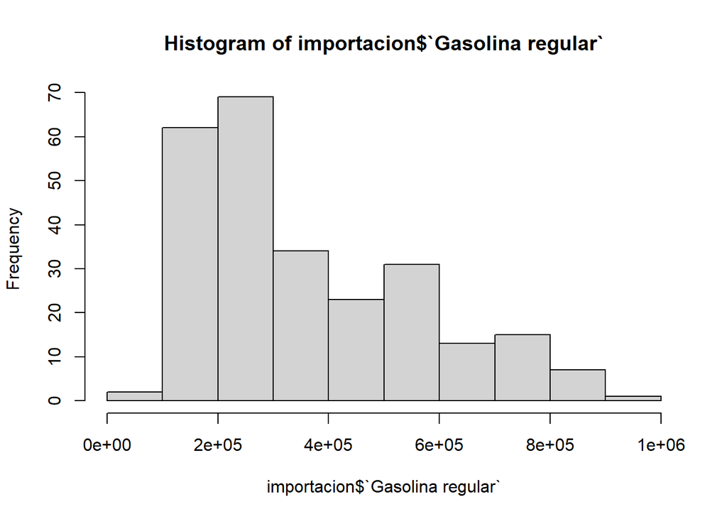

```r
hist(x = importacion$`Gasolina regular`)
```

La variable gasolina alto azufre tiene el siguiente comportamiento:

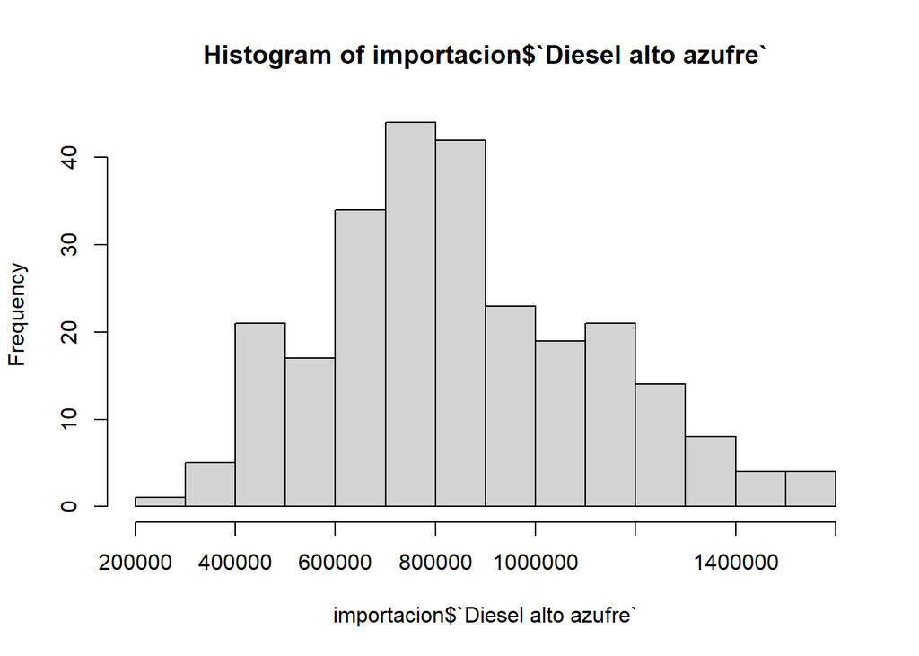

```r
hist(x = importacion$`Diesel alto azufre`)
```

## Analisis Exploratorio

### ¿Cuál fue la fecha con mayor cantidad de importaciones de gasolina superior?

```r
superior <- importacion[order(-importacion$`Gasolina superior`),]
superior<- head(superior,10)
superior<- superior[,1:2]
superior
```

```
## # A tibble: 10 x 2
##    Fecha      `Gasolina superior`
##    <date>                   <dbl>
##  1 2021-04-01            1227174.
##  2 2022-01-01             947208.
##  3 2021-03-01             850335.
##  4 2020-03-01             809640.
##  5 2017-12-01             803217.
##  6 2019-12-01             797581.
##  7 2018-07-01             784602.
##  8 2020-12-01             777451.
##  9 2016-03-01             771024.
## 10 2017-07-01             769214.
```

Tal como se observa la fecha con mayor importacion de gasolina superior es *2021-04-01* con una cantidad de *1227173*

### ¿Cuál fue la fecha con menor cantidad de importaciones de gasolina superior?

```r
inferior <- importacion[order(importacion$`Gasolina superior`),]
inferior<- head(inferior,10)
inferior<- inferior[,1:2]
inferior
```

```
## # A tibble: 10 x 2
##    Fecha      `Gasolina superior`
##    <date>                   <dbl>
##  1 2020-05-01             170292.
##  2 2005-09-01             193484.
##  3 2001-07-01             195072.
##  4 2007-04-01             203441.
##  5 2008-01-01             204788.
##  6 2010-11-01             241063.
##  7 2008-08-01             241881.
##  8 2001-02-01             243091.
##  9 2002-03-01             246293.
## 10 2004-07-01             249711.
```

Tal como se observa la fecha con menor importacion es *2020-05-01* con una cantidad de *170292*

### ¿Cuál fue la fecha con mayor cantidad de importaciones de gasolina Diesel?

```r
dieselImpo <- importacion[order(-importacion$`Diesel alto azufre`),]
dieselImpo<- head(dieselImpo,10)
dieselImpo<- dieselImpo[c('Fecha','Diesel alto azufre')]
dieselImpo
```

```
## # A tibble: 10 x 2
##    Fecha      `Diesel alto azufre`
##    <date>                    <dbl>
##  1 2014-01-01             1595699.
##  2 2018-05-01             1592580.
##  3 2019-03-01             1550053.
##  4 2021-10-01             1542474.
##  5 2016-03-01             1498845.
##  6 2021-06-01             1440106.
##  7 2022-01-01             1438571.
##  8 2017-04-01             1406022.
##  9 2020-03-01             1367335.
## 10 2017-03-01             1351788.
```

### ¿Cuál fue la fecha con menor cantidad de importaciones de gasolina Diesel?

```r
diesel_menor_impor <- importacion[order(importacion$`Diesel alto azufre`),]
diesel_menor_impor<- head(diesel_menor_impor,10)
diesel_menor_impor<- diesel_menor_impor[c('Fecha','Diesel alto azufre')]
diesel_menor_impor
```

```
## # A tibble: 10 x 2
##    Fecha      `Diesel alto azufre`
##    <date>                    <dbl>
##  1 2005-09-01              229765.
##  2 2001-07-01              302350.
##  3 2001-09-01              321953.
##  4 2008-10-01              344273.
##  5 2002-08-01              346225
##  6 2006-06-01              361208.
##  7 2002-04-01              424667.
##  8 2006-11-01              431875.
##  9 2002-03-01              432538.
## 10 2003-10-01              433085.
```

Tal como se observa la fecha con menor importacion es *2005-09-01* con una cantidad de *229764*

### ¿Cuál fue la fecha con mayor cantidad de importaciones de gasolina Regular?

```r
regular_impo <- importacion[order(-importacion$`Gasolina regular`),]
regular_impo<- head(regular_impo,10)
regular_impo<- regular_impo[c('Fecha','Gasolina regular')]
regular_impo
```

```
## # A tibble: 10 x 2
##    Fecha      `Gasolina regular`
##    <date>                  <dbl>
##  1 2022-04-01            906104.
##  2 2019-08-01            896841.
##  3 2019-04-01            867761.
##  4 2020-10-01            861841.
##  5 2022-01-01            848903.
##  6 2021-09-01            844430.
##  7 2021-07-01            833732.
##  8 2021-06-01            833545.
##  9 2019-11-01            791039.
## 10 2021-12-01            785314.
```

### ¿Cuál fue la fecha con menor cantidad de importaciones de gasolina Regular?

```r
regular_impo_menor <- importacion[order(importacion$`Gasolina regular`),]
regular_impo_menor<- head(regular_impo_menor,10)
regular_impo_menor<- regular_impo_menor[c('Fecha','Gasolina regular')]
regular_impo_menor
```

```
## # A tibble: 10 x 2
##    Fecha      `Gasolina regular`
##    <date>                  <dbl>
##  1 2005-09-01             81015.
##  2 2007-04-01             94845.
##  3 2002-03-01            104674.
##  4 2005-12-01            107374
##  5 2008-01-01            107886.
##  6 2001-02-01            123116.
##  7 2001-04-01            127339.
##  8 2004-06-01            133341
##  9 2003-07-01            133668.
## 10 2006-05-01            134212.
```

Tal como se observa la fecha con menor importacion es *2005-09-01* con una cantidad de *81015*

### ¿Qué tipo de gasolina ha sido la más importada hasta la fecha?

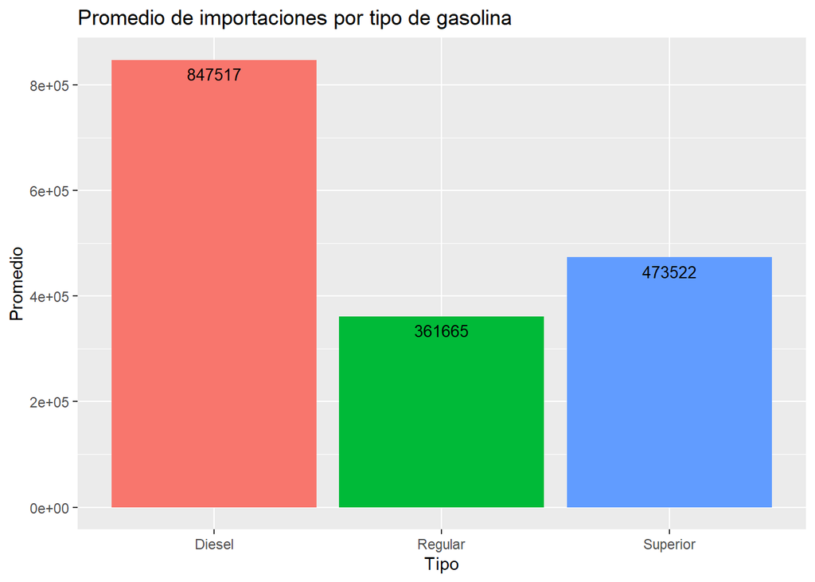

```r
ask1<-data.frame(Tipo=c('Superior','Regular','Diesel'),
                 Promedio=c(mean(importacion$`Gasolina superior`),mean(importacion$`Gasolina regular`),mean(importacion$`Diesel alto azufre`)))

ask1_chart<-ggplot(data=ask1, aes(x=Tipo, y=Promedio, fill=Tipo)) +
  geom_bar(stat="identity", position=position_dodge())+
  geom_text(aes(label=as.integer(Promedio)), vjust=1.6, color="black",
            position = position_dodge(0.9), size=3.5)+
  labs(title="Promedio de importaciones por tipo de gasolina", y="Promedio")+
  theme(legend.position="none")


ask1_chart
```

Como se observa en la grafica anterior el tipo de gasolina con mayor importacion es Diesel, lo cual tiene coherencia debido que en Guatemala se utiliza muchos vehiculos categorizados como carga pesada, sobre todo en las areas rurales y agricolas, ademas que este tipo de gasolina tiende a ser mas economica que los demas, por ello se busca vehiculos que la utilicen para economizar gastos.